```r
options(OutDec = ".")  # Asegurar punto decimal en este chunk

# Establecer semilla aleatoria
set.seed(sample(1:10000, 1))

# Aleatorización del precio original
precios_base <- c(50000, 60000, 75000, 80000, 90000, 100000, 120000, 125000,
                 150000, 180000, 200000, 250000, 300000, 350000, 400000, 450000, 500000)
precio_original <- sample(precios_base, 1)

# Aleatorización del porcentaje de descuento
porcentajes <- c(10, 15, 20, 25, 30, 33, 40, 50)
porcentaje_descuento <- sample(porcentajes, 1)

# Aleatorización del contexto del problema
contextos_articulos <- list(
  c("un televisor", "televisor", "electrónico"),
  c("un celular", "celular", "electrónico"),
  c("un computador", "computador", "electrónico"),
  c("una lavadora", "lavadora", "electrodoméstico"),
  c("un refrigerador", "refrigerador", "electrodoméstico"),
  c("una bicicleta", "bicicleta", "artículo deportivo"),
  c("un sofá", "sofá", "mueble"),
  c("una mesa", "mesa", "mueble"),
  c("un vestido", "vestido", "prenda"),
  c("un traje", "traje", "prenda"),
  c("unos zapatos", "zapatos", "calzado"),
  c("un reloj", "reloj", "accesorio"),
  c("una joya", "joya", "accesorio"),
  c("un libro", "libro", "artículo educativo"),
  c("un boleto de avión", "boleto", "servicio")
)
contexto_seleccionado <- sample(contextos_articulos, 1)[[1]]
articulo <- contexto_seleccionado[1]
tipo_articulo <- contexto_seleccionado[2]
categoria <- contexto_seleccionado[3]

# Aleatorización de términos para el enunciado
terminos_ahorro <- c("ahorró", "economizó", "se descontó", "dejó de pagar", "redujo del pago")
termino_ahorro <- sample(terminos_ahorro, 1)

terminos_descuento <- c("descuento", "rebaja", "reducción", "oferta", "promoción")
termino_descuento <- sample(terminos_descuento, 1)

terminos_compra <- c("comprar", "adquirir", "obtener", "conseguir")
termino_compra <- sample(terminos_compra, 1)

terminos_costo <- c("costaba", "tenía un precio de", "valía", "estaba marcado en")
termino_costo <- sample(terminos_costo, 1)

terminos_procedimiento <- c("procedimientos", "métodos", "cálculos", "operaciones", "fórmulas")
termino_procedimiento <- sample(terminos_procedimiento, 1)

# Cálculos para las opciones
# Valor del descuento (ahorro)
valor_descuento <- precio_original * porcentaje_descuento / 100
# Precio final después del descuento
precio_final <- precio_original - valor_descuento
# Factor para el precio final (1 - porcentaje_descuento/100)
factor_precio_final <- 1 - porcentaje_descuento/100

# Generar las opciones de respuesta
# Opción A: Fracción equivalente al porcentaje × precio
fraccion <- switch(as.character(porcentaje_descuento),
                  "10" = "\\frac{1}{10}",
                  "15" = "\\frac{3}{20}",
                  "20" = "\\frac{1}{5}",
                  "25" = "\\frac{1}{4}",
                  "30" = "\\frac{3}{10}",
                  "33" = "\\frac{1}{3}",
                  "40" = "\\frac{2}{5}",
                  "50" = "\\frac{1}{2}")

opcion_a <- paste0(fraccion, " \\times ", format(precio_original, big.mark=".", decimal.mark=","))

# Opción B: Decimal equivalente al porcentaje × precio
decimal <- porcentaje_descuento / 100
opcion_b <- paste0(format(decimal, nsmall=2, decimal.mark=","), " \\times ", format(precio_original, big.mark=".", decimal.mark=","))

# Opción C: Fórmula estándar de porcentaje
opcion_c <- paste0("\\frac{", format(precio_original, big.mark=".", decimal.mark=","), " \\times ", porcentaje_descuento, "}{100}")

# Opción D: Factor para precio final × precio (NO calcula el ahorro)
opcion_d <- paste0(format(factor_precio_final, nsmall=2, decimal.mark=","), " \\times ", format(precio_original, big.mark=".", decimal.mark=","))

# Crear vector con todas las opciones
opciones <- c(opcion_a, opcion_b, opcion_c, opcion_d)

# La respuesta correcta es la opción D (que NO calcula el ahorro)
indice_correcto <- 4

# Crear el vector de solución para r-exams (1 para la respuesta correcta, 0 para las incorrectas)
solucion <- rep(0, 4)
solucion[indice_correcto] <- 1

# Formatear valores para Python
precio_original_formateado <- gsub("\\.", ",", format(precio_original, big.mark="."))
valor_descuento_formateado <- gsub("\\.", ",", format(round(valor_descuento), big.mark="."))
```

```r
options(OutDec = ".")  # Asegurar punto decimal en este chunk

# Crear un archivo Python temporal con el código
archivo_python <- tempfile(fileext = ".py")

# Preparar el código Python sin usar sprintf para evitar problemas con los marcadores %
codigo_python <- paste0('
import matplotlib
matplotlib.use("Agg")  # Usar backend no interactivo
import matplotlib.pyplot as plt
import numpy as np
from matplotlib.patches import Rectangle
import matplotlib.patheffects as path_effects

# Configuración de colores
color_precio_original = "#3498db"  # Azul
color_descuento = "#e74c3c"        # Rojo
color_precio_final = "#2ecc71"     # Verde

# Crear figura
fig, ax = plt.subplots(figsize=(8, 4))

# Datos para la visualización
precio_original = ', precio_original, '
porcentaje_descuento = ', porcentaje_descuento, '
valor_descuento = precio_original * porcentaje_descuento / 100
precio_final = precio_original - valor_descuento

# Crear barras para representar los precios
bar_width = 0.4
x_pos = [0, 1]

# Barra para precio original
ax.bar(x_pos[0], precio_original, bar_width, color=color_precio_original,
       edgecolor="black", linewidth=1.5, label="Precio original")

# Barra para precio final y descuento
ax.bar(x_pos[1], precio_final, bar_width, color=color_precio_final,
       edgecolor="black", linewidth=1.5, label="Precio final")
ax.bar(x_pos[1], valor_descuento, bar_width, bottom=precio_final,
       color=color_descuento, edgecolor="black", linewidth=1.5,
       hatch="///", label="Descuento (', porcentaje_descuento, '%)")

# Añadir etiquetas con valores
def add_value_label(x, y, value, color="black", fontsize=10, fontweight="bold"):
    text = ax.text(x, y, f"${value:,.0f}".replace(",", "."),
                  ha="center", va="bottom", fontsize=fontsize, fontweight=fontweight)
    text.set_path_effects([path_effects.withStroke(linewidth=3, foreground="white")])
    return text

# Etiqueta para precio original
add_value_label(x_pos[0], precio_original, precio_original)

# Etiqueta para precio final
add_value_label(x_pos[1], precio_final/2, precio_final)

# Etiqueta para descuento
add_value_label(x_pos[1], precio_final + valor_descuento/2, valor_descuento)

# Añadir porcentaje de descuento
ax.text(x_pos[1] + 0.25, precio_final + valor_descuento/2,
       f"{porcentaje_descuento}%", ha="left", va="center",
       fontsize=12, fontweight="bold", color=color_descuento)

# Configurar ejes
ax.set_xticks(x_pos)
ax.set_xticklabels(["Precio original", "Precio con descuento"], fontsize=10, fontweight="bold")
ax.set_ylabel("Precio ($)", fontsize=10, fontweight="bold")
ax.set_title("Representación del descuento", fontsize=14, fontweight="bold", pad=15)

# Eliminar bordes superiores y derechos
ax.spines["top"].set_visible(False)
ax.spines["right"].set_visible(False)

# Añadir leyenda
ax.legend(loc="upper center", bbox_to_anchor=(0.5, -0.15), ncol=3, frameon=False, fontsize=9)

# Crear una imagen separada para las fórmulas
fig_formula = plt.figure(figsize=(6, 1.2))
plt.axis("off")
plt.text(0.5, 0.7, "Ahorro = Precio original × Porcentaje de descuento ÷ 100",
         ha="center", va="center", fontsize=10)

# Formatear los valores directamente en Python sin el símbolo $
precio_formateado = "{:,.0f}".format(precio_original).replace(",", ".")
descuento_formateado = "{:,.0f}".format(valor_descuento).replace(",", ".")

# Usar formato simple sin símbolos $ para evitar problemas
ejemplo_texto = "Ejemplo: " + precio_formateado + " × " + str(porcentaje_descuento) + "% ÷ 100 = " + descuento_formateado
plt.text(0.5, 0.3, ejemplo_texto,
         ha="center", va="center", fontsize=10)

plt.tight_layout()
plt.savefig("formula_descuento.png", dpi=150, bbox_inches="tight", transparent=True)
plt.close(fig_formula)

# Ajustar diseño
plt.tight_layout(rect=[0, 0.05, 1, 0.95])

# Guardar en múltiples formatos para asegurar compatibilidad
plt.savefig("visualizacion_descuento.png", dpi=150, bbox_inches="tight", format="png")
plt.savefig("visualizacion_descuento.pdf", dpi=150, bbox_inches="tight", format="pdf")
plt.close()
')

# Escribir el código Python en el archivo temporal
writeLines(codigo_python, archivo_python)

# Ejecutar el archivo Python
py_run_file(archivo_python)

# Eliminar el archivo temporal
unlink(archivo_python)
```

# Question

Se quiere saber cuánto dinero ahorró una persona al comprar un vestido que costaba $300.000 y tenía un oferta del 20%.

¿Cuál de los siguientes operaciones **NO** permite calcular este valor?

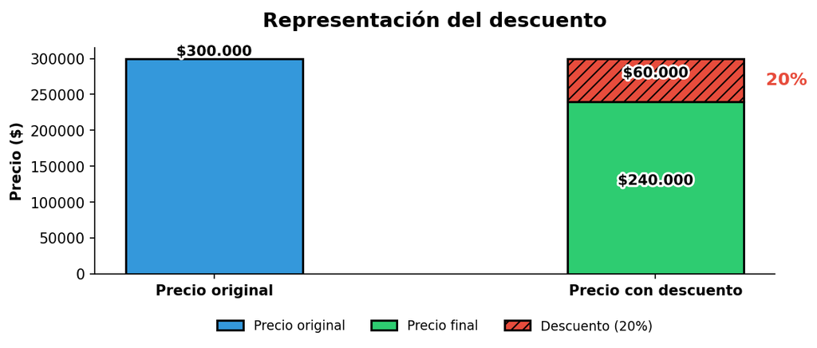

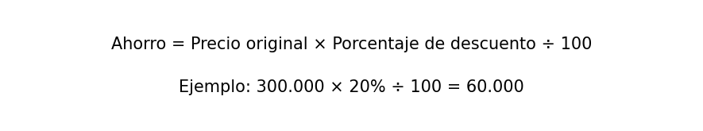

## Answerlist

- A. $\frac{1}{5} \times 300.000$
- B. $0,20 \times 300.000$
- C. $\frac{300.000 \times 20}{100}$
- D. $0,80 \times 300.000$

# Solution

Para resolver este problema, debemos analizar cada uno de los procedimientos propuestos y determinar cuál **NO** permite calcular el ahorro obtenido al aplicar un descuento del 20% a un artículo que cuesta $300.000.

#### Opción B: $0,20 \times 300.000$

Esta opción representa el porcentaje de descuento expresado como decimal multiplicado por el precio original: - 0,20 es equivalente a 20% - Al multiplicar este decimal por el precio original, obtenemos el valor del descuento: $0,20 \times 300.000 = 60.000$ - **Este procedimiento SÍ permite calcular el ahorro.**

#### Opción C: $\frac{300.000 \times 20}{100}$

Esta opción representa la fórmula estándar para calcular un porcentaje del precio original: - $\frac{300.000 \times 20}{100} = 60.000$ - **Este procedimiento SÍ permite calcular el ahorro.**

#### Opción D: $0,80 \times 300.000$

Esta opción representa el factor para calcular el precio final (después del descuento) multiplicado por el precio original: - 0,80 es equivalente a (1 - 20/100) - Al multiplicar este factor por el precio original, obtenemos el precio final después del descuento: $0,80 \times 300.000 = 240.000$ - Este cálculo nos da el precio final después del descuento, NO el ahorro. - **Este procedimiento NO permite calcular el ahorro.**

### Verificación matemática:

- Precio original: $300.000
- Porcentaje de descuento: 20%
- Valor del descuento (ahorro): $60.000 (calculado como 20% de $300.000)
- Precio final: $240.000 (calculado como $300.000 - $60.000)

### Conclusión:

La opción D ($0,80 \times 300.000$) es la única que **NO** permite calcular el ahorro, ya que calcula el precio final después del descuento en lugar del monto ahorrado.

## Answerlist

- Falso
- Falso
- Falso
- Verdadero

# Meta-information

exname: descuentos_porcentajes extype: schoice exsolution: 0001 exshuffle: TRUE exsection: Aritmética|Porcentajes|Descuentos exextra[ICFES,character]: Competencia: Interpretación y representación exextra[ICFES,character]: Afirmación: Comprende y transforma la información cuantitativa y esquemática presentada en distintos formatos exextra[ICFES,character]: Evidencia: Da cuenta de las características básicas de la información presentada en diferentes formatos como series, gráficas, tablas y esquemas exextra[ICFES,character]: Nivel: Medio